# Data Frames, Manejo de Fechas y Horas

Gina Berrones

11/10/2020

### Importación de Datos

#### Datos tipo (.txt)

##### Podemos utilizar la función read.table()

##### ejemplo <- read.table(“ejemplo.txt”, header=T, sep=”, dec=”.”, stringsAsFactors=TRUE)

##### Qué significa cada parámetro?

- header: indica si el archivo tiene encabezado o no. Es decir, si es verdadero o falso que el data frame presenta en su primera línea el nombre de las variables o no.
- sep: hace referencia al modo en el que se hallan separados los datos (sep=”;”, sep=”,”, sep=” ”, sep=”. La opción por defecto de separación es el espacio en blanco. *dec: si importamos variables que tienen decimales, R por defecto interpreta que trabajamos con el punto decimal (dec=”.”). Si deseamos utilizar la coma como marca decimal lo hacemos a través de (dec=”,”).* stringsAsFactors: es un argumento donde se indica si los caracteres deben ser tratados como factores o solamente como caracteres.

##### Vamos a leer el archivo csv de la clase anterior o su propio archivo

```r
estacion <- read.csv("carapungo.csv", header = TRUE, sep = ",", stringsAsFactors = FALSE)
```

### Fechas y Horas

#### R tiene funciones que permiten trabajar con fechas y horas. Además, paquetes o librerías como “lubridate” hacen que sea más fácil trabajar con estas fechas y horas

```r
install.packages("lubridate")
library(lubridate)
```

#### Cómo obtenemos la fecha y tiempo acual

```r
Sys.timezone()
```

```
## [1] "America/Guayaquil"
```

```r
Sys.Date()
```

```
## [1] "2020-11-10"
```

```r
Sys.time()
```

```
## [1] "2020-11-10 00:22:29 -05"
```

```r
# Si usamos la librería lubridate:
now()
```

```
## [1] "2020-11-10 00:22:29 -05"
```

#### Convertir caracteres a fechas

##### Cuando las fechas y horas son importadas a R serán a menudo en forma de caracter. Por lo tanto se requiere convertirlas a fechas. Podemos también tener múltiples caracteres que podríamos querer unir para crear una variable de fecha.

##### Para convertir un caracter que ya está en formato fecha (YYYY-MM-DD) a un objeto tipo fecha usamos as.Date()

```r
x <- c("2020-05-01", "2020-06-01", "2020-07-01")
as.Date(x)
```

```
## [1] "2020-05-01" "2020-06-01" "2020-07-01"
```

```r
#Utilizando el archivo de la estacion Carapungo:
as.Date(estacion$FECHA.HORA)
```

```
##  [1] "2020-11-08" "2020-11-08" "2020-11-08" "2020-11-08" "2020-11-08"
##  [6] "2020-11-08" "2020-11-08" "2020-11-08" "2020-11-08" "2020-11-08"
## [11] "2020-11-08" "2020-11-08" "2020-11-08" "2020-11-08" "2020-11-08"
## [16] "2020-11-08" "2020-11-08" "2020-11-08" "2020-11-08" "2020-11-08"
## [21] "2020-11-08" "2020-11-07"
```

##### Noten que el formato de fecha por default en R es YYYY-MM-DD; entonces, si el caracter está en un formato diferente se debe incorporar el argumento “format”. Hay múltiples formatos para las fechas, para obtener una lista completa de opciones de formatos escribimos en la consola ?strftime

```r
y <- c("04/01/2020", "04/02/2020", "04/03/2020")
as.Date(y, format = "%m/%d/%Y")
```

```
## [1] "2020-04-01" "2020-04-02" "2020-04-03"
```

```r
#Si usamos la librería "lubridate"
ymd(x)
```

```
## [1] "2020-05-01" "2020-06-01" "2020-07-01"
```

```r
mdy(y)
```

```
## [1] "2020-04-01" "2020-04-02" "2020-04-03"
```

##### Cómo convertimos toda nuestra variable de fecha que tiene clase caracter a formato fecha y hora

##### Qué observan al ejecutar la siguiente función?

```r
estacion$FECHA.HORA <- as.Date(estacion$FECHA.HORA, format = "%Y-%m-%d %H:%M")
class(estacion$FECHA.HORA)
```

```
## [1] "Date"
```

##### Luego de haber observado que falencias tuvimos con el argumento as.Date, vamos a utilizar la función as.POSIXct

```r
estacion <- read.csv("carapungo.csv", header = TRUE, sep = ",", stringsAsFactors = FALSE)
estacion$FECHA.HORA <- as.POSIXct(estacion$FECHA.HORA, format = "%Y-%m-%d %H:%M")
```

#### Creación de secuencias de tiempo con as.POSIXct y la librería “lubridate”

```r
seq(as.POSIXct("2020-01-01 0:00"), as.POSIXct("2020-01-01 20:00"), by = "hour")
```

```
##  [1] "2020-01-01 00:00:00 -05" "2020-01-01 01:00:00 -05"
##  [3] "2020-01-01 02:00:00 -05" "2020-01-01 03:00:00 -05"
##  [5] "2020-01-01 04:00:00 -05" "2020-01-01 05:00:00 -05"
##  [7] "2020-01-01 06:00:00 -05" "2020-01-01 07:00:00 -05"
##  [9] "2020-01-01 08:00:00 -05" "2020-01-01 09:00:00 -05"
## [11] "2020-01-01 10:00:00 -05" "2020-01-01 11:00:00 -05"
## [13] "2020-01-01 12:00:00 -05" "2020-01-01 13:00:00 -05"
## [15] "2020-01-01 14:00:00 -05" "2020-01-01 15:00:00 -05"
## [17] "2020-01-01 16:00:00 -05" "2020-01-01 17:00:00 -05"
## [19] "2020-01-01 18:00:00 -05" "2020-01-01 19:00:00 -05"
## [21] "2020-01-01 20:00:00 -05"
```

```r
#Con lubridate
seq(ymd_hm("2020-01-01 0:00"), ymd_hm("2020-01-01 20:00"), by = "hour")
```

```
##  [1] "2020-01-01 00:00:00 UTC" "2020-01-01 01:00:00 UTC"
##  [3] "2020-01-01 02:00:00 UTC" "2020-01-01 03:00:00 UTC"
##  [5] "2020-01-01 04:00:00 UTC" "2020-01-01 05:00:00 UTC"
##  [7] "2020-01-01 06:00:00 UTC" "2020-01-01 07:00:00 UTC"
##  [9] "2020-01-01 08:00:00 UTC" "2020-01-01 09:00:00 UTC"
## [11] "2020-01-01 10:00:00 UTC" "2020-01-01 11:00:00 UTC"
## [13] "2020-01-01 12:00:00 UTC" "2020-01-01 13:00:00 UTC"
## [15] "2020-01-01 14:00:00 UTC" "2020-01-01 15:00:00 UTC"
## [17] "2020-01-01 16:00:00 UTC" "2020-01-01 17:00:00 UTC"
## [19] "2020-01-01 18:00:00 UTC" "2020-01-01 19:00:00 UTC"
## [21] "2020-01-01 20:00:00 UTC"
```

#### Creación de secuencias de tiempo y exportación a archivo .csv utilizando la librería lubridate

```r
dates <- seq(ymd_hm("2020-01-01 05:00"), ymd_hm("2020-01-01 06:00"), by = "min")
dat <- as.data.frame(dates)
setwd("/home/gina/Documents/iniciacion R")
write.csv(dat, file = "fechamin.csv")
```

#### Ahora que tenemos ya el tiempo en el formato correcto vamos a hacer unos plots sencillos

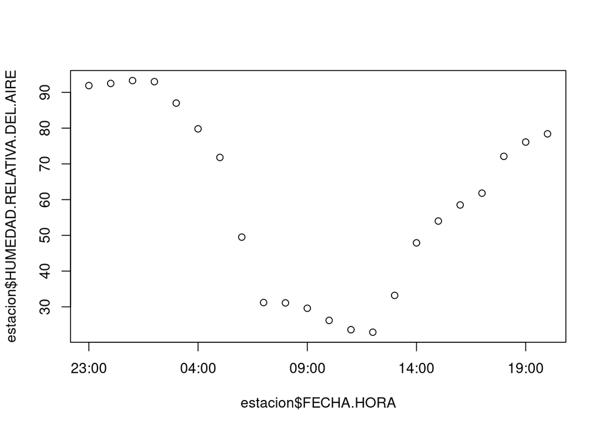

```r
plot (estacion$FECHA.HORA, estacion$HUMEDAD.RELATIVA.DEL.AIRE)
```

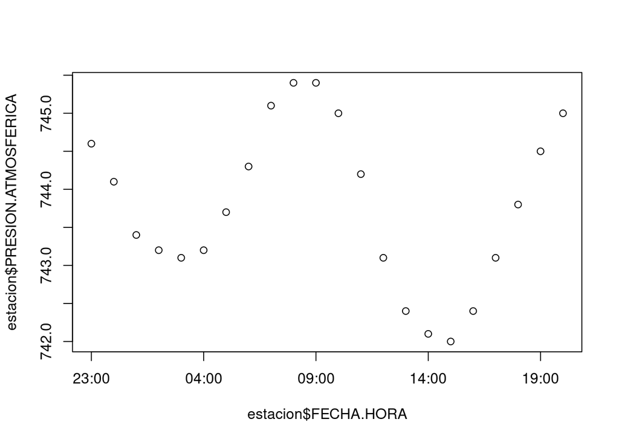

```r
plot (estacion$FECHA.HORA, estacion$PRESION.ATMOSFERICA)
```

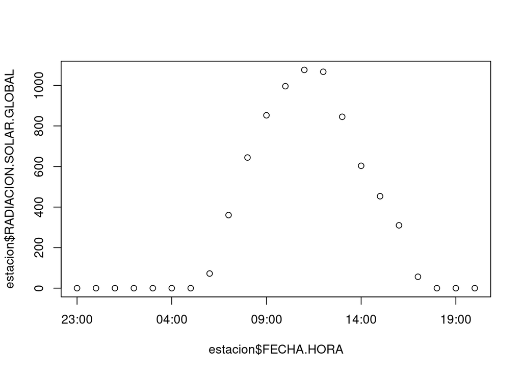

```r
plot (estacion$FECHA.HORA, estacion$RADIACION.SOLAR.GLOBAL)
```

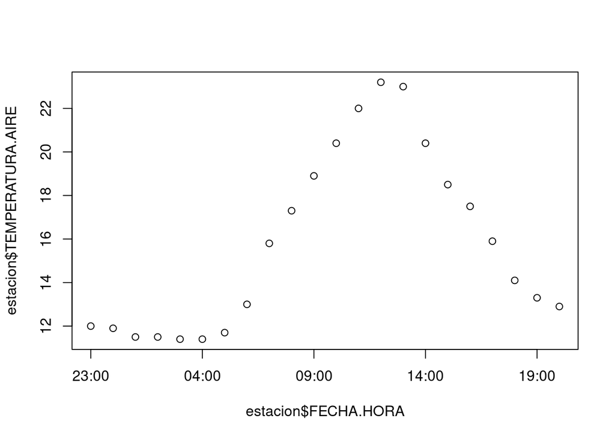

```r
plot (estacion$FECHA.HORA, estacion$TEMPERATURA.AIRE)
```

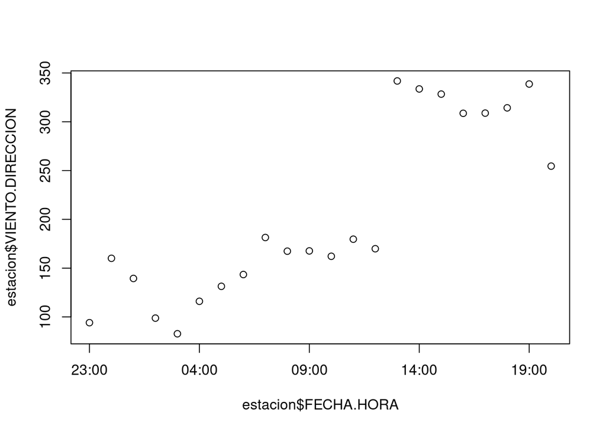

```r
plot (estacion$FECHA.HORA, estacion$VIENTO.DIRECCION)
```

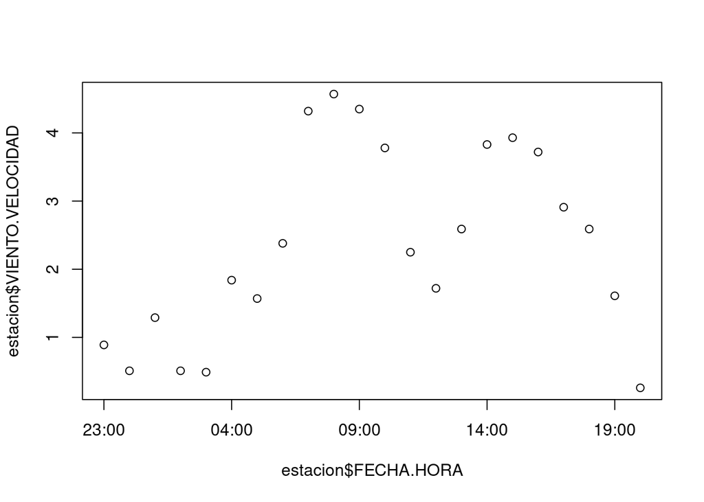

```r
plot (estacion$FECHA.HORA, estacion$VIENTO.VELOCIDAD)
```